# Clustering and Anomaly Detection

## Clustering & Anomaly Detection Using `scikit-learn` and `scipy`

I explore the concepts of clustering and anomaly detection using Python's `scikit-learn` and `scipy` libraries.

```python
import warnings
warnings.simplefilter("ignore")
import pandas as pd
import numpy as np
import sklearn as sk
import matplotlib.pyplot as plt
import random as rand
import itertools as it

from pandas import DataFrame, Series

from scipy.cluster import hierarchy as hier
from scipy.cluster.hierarchy import dendrogram, linkage
from scipy.spatial.distance import pdist

from sklearn import preprocessing
from sklearn.preprocessing import StandardScaler, RobustScaler
from sklearn.decomposition import PCA
from sklearn.manifold import MDS
from sklearn.cluster import KMeans, AgglomerativeClustering, DBSCAN
from sklearn.neighbors import NearestNeighbors
from sklearn.metrics import accuracy_score, silhouette_score
from sklearn.model_selection import StratifiedKFold
```

```python
%matplotlib inline
```

### Data

I will be working with the Epileptic Seizure Recognition Dataset developed at Rochester Institute of Technology. In this dataset each row is a sample of the EEG recording at a different point in time. The dataset contains 179 columns, the first 178 are the EEG features while the last column represents the label y {1, 2, 3, 4, 5}. All subjects falling in classes 2, 3, 4, and 5 are subjects who did not have epileptic seizure. Only subjects in class 1 have epileptic seizure. The class labels will not be used for clustering - they will just be used for plotting the data. The only change that was made to the original dataset was removing the first column, which contained the row indexes. Additional information about the dataset [here](https://archive.ics.uci.edu/ml/datasets/Epileptic+Seizure+Recognition).

```python
# reading the Epileptic Seizure Dataset
dataset = pd.read_csv("seizure_edited.csv", header = 0)
print(dataset.shape)

# split the dataset into features and labels
labels = dataset['y']
data = dataset.drop('y', axis = 1)

dataset.head(10)
```

```
(11500, 179)
```

|  | X1 | X2 | X3 | X4 | X5 | X6 | X7 | X8 | X9 | X10 | ... | X170 | X171 | X172 | X173 | X174 | X175 | X176 | X177 | X178 | y |
| --- | --- | --- | --- | --- | --- | --- | --- | --- | --- | --- | --- | --- | --- | --- | --- | --- | --- | --- | --- | --- | --- |
| 0 | 135 | 190 | 229 | 223 | 192 | 125 | 55 | -9 | -33 | -38 | ... | -17 | -15 | -31 | -77 | -103 | -127 | -116 | -83 | -51 | 4 |
| 1 | 386 | 382 | 356 | 331 | 320 | 315 | 307 | 272 | 244 | 232 | ... | 164 | 150 | 146 | 152 | 157 | 156 | 154 | 143 | 129 | 1 |
| 2 | -32 | -39 | -47 | -37 | -32 | -36 | -57 | -73 | -85 | -94 | ... | 57 | 64 | 48 | 19 | -12 | -30 | -35 | -35 | -36 | 5 |
| 3 | -105 | -101 | -96 | -92 | -89 | -95 | -102 | -100 | -87 | -79 | ... | -82 | -81 | -80 | -77 | -85 | -77 | -72 | -69 | -65 | 5 |
| 4 | -9 | -65 | -98 | -102 | -78 | -48 | -16 | 0 | -21 | -59 | ... | 4 | 2 | -12 | -32 | -41 | -65 | -83 | -89 | -73 | 5 |
| 5 | 55 | 28 | 18 | 16 | 16 | 19 | 25 | 40 | 52 | 66 | ... | -12 | -31 | -42 | -54 | -60 | -64 | -60 | -56 | -55 | 5 |
| 6 | -55 | -9 | 52 | 111 | 135 | 129 | 103 | 72 | 37 | 0 | ... | -125 | -99 | -79 | -62 | -41 | -26 | 11 | 67 | 128 | 4 |
| 7 | 1 | -2 | -8 | -11 | -12 | -17 | -15 | -16 | -18 | -17 | ... | -79 | -91 | -97 | -88 | -76 | -72 | -66 | -57 | -39 | 2 |
| 8 | -278 | -246 | -215 | -191 | -177 | -167 | -157 | -139 | -118 | -92 | ... | -400 | -379 | -336 | -281 | -226 | -174 | -125 | -79 | -40 | 1 |
| 9 | 8 | 15 | 13 | 3 | -6 | -8 | -5 | 4 | 25 | 41 | ... | 49 | 31 | 11 | -5 | -17 | -19 | -15 | -15 | -11 | 4 |

10 rows × 179 columns

### Part 1: Data scaling & dimensionality reduction with PCA

Both K-means and DBSCAN break down in high dimensions, as distance (and thus density) become less meaningful in high dimensions. So, before we run either of these clustering algorithms, we want to reduce the dimensionality of our dataset. We must scale the data prior to running PCA.

```python
data = StandardScaler().fit_transform(data)
pca = PCA(n_components=.95, svd_solver='full')
pca_data = pca.fit_transform(data)
data = DataFrame(pca_data)
data.head()
```

|  | 0 | 1 | 2 | 3 | 4 | 5 | 6 | 7 | 8 | 9 | ... | 29 | 30 | 31 | 32 | 33 | 34 | 35 | 36 | 37 | 38 |
| --- | --- | --- | --- | --- | --- | --- | --- | --- | --- | --- | --- | --- | --- | --- | --- | --- | --- | --- | --- | --- | --- |
| 0 | -0.137475 | -1.146419 | 0.836893 | -0.071085 | -0.177048 | -0.825731 | 0.777044 | 0.337638 | 2.744494 | -0.734679 | ... | 0.994987 | -2.154933 | 1.053161 | -0.090869 | 0.254414 | -0.225816 | -1.055100 | -0.320229 | 0.195361 | -0.102763 |
| 1 | -1.703794 | -3.643195 | 6.153822 | 8.033432 | 4.549536 | 5.892971 | 3.758370 | -5.804916 | 4.187441 | 11.192247 | ... | -5.864539 | -7.613729 | 5.082526 | -2.786232 | 1.832683 | 2.158849 | 2.594621 | -0.218890 | 0.437192 | -3.813345 |
| 2 | 0.495650 | -0.261660 | 0.931210 | -0.663789 | 1.587618 | -1.604942 | -0.880830 | -1.591959 | -0.400873 | -1.435073 | ... | 0.124686 | 0.027333 | 0.946955 | 0.827331 | -0.611872 | 0.389295 | -0.490630 | 0.015729 | -0.180175 | 0.048221 |
| 3 | -0.174219 | 0.249557 | -0.073646 | -0.108047 | 1.615415 | -3.136337 | -0.559638 | -3.032901 | -0.222729 | -1.465921 | ... | -0.322617 | 0.162047 | -0.002372 | -0.053858 | -0.205829 | -0.160254 | 0.048781 | 0.088260 | 0.201175 | 0.139328 |
| 4 | -0.239163 | 0.117304 | 0.486502 | -0.530629 | 0.187739 | -0.371186 | -0.045861 | 0.481596 | -0.094907 | 0.541482 | ... | -0.360548 | -0.399276 | 0.100645 | -0.334393 | 0.155918 | -0.114335 | 0.262911 | -0.916693 | 0.658297 | -0.122812 |

5 rows × 39 columns

```python
def scatter(data, labels, numPoints = 300):

    numEntries = data.shape[0]
    start = rand.randint(0, numEntries - numPoints)
    end = start + numPoints
    data = data.iloc[start:end, :]
    labels = labels.iloc[start:end]

    mds = MDS(n_components=2)
    mds_data = mds.fit_transform(data.iloc[:, :-1])
    plt.scatter(mds_data[:, 0], mds_data[:, 1], c=labels, s=50)
    plt.show()
```

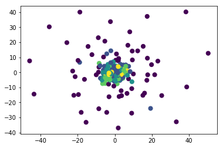

```python
scatter(data, labels, numPoints = 300)
```